# W1_Exercise Solutions

The core tidyverse includes the packages that you’re likely to use in everyday data analyses. Let’s explore some of the functions using a dataset of passengers on the Titanic. This exercise is a modification of the DataCamp [Introduction to Tidyverse](https://github.com/datacamp/datacamp_facebook_live_intro_to_tidyverse).

You can execute chunks by clicking the *Run* button (green arrow) within the chunk or by placing your cursor inside it and pressing *Cmd+Shift+Enter* or *Ctrl+Shift+Enter* on Windows.

First, we will install the tidyverse package

```r
# Install the tidyverse
#install.packages("tidyverse")
```

Now that you’ve installed the tidyverse, it’s time to load your package and data. Check out some of the observations.

In this code along session, you’ll be exploring the [Titanic dataset](https://www.kaggle.com/c/titanic), where each observation is a person and each variable is a feature such as “Name”, “Age” and “Survived” (or not). We will be exploring this data using tidyverse with a focus on [dplyr](http://dplyr.tidyverse.org/) for data wrangling and [ggplot2](http://ggplot2.tidyverse.org/) for data visualization

Load your data:

```r
# Import the Tidyverse
library(tidyverse)
# Import data
passengers <- read_csv("data/train.csv") # how to name things readDOTcsv  vs read_csv
# Check out the first several observations of your dataframe
 #whats a dataframe
passengers #is data really binary? where did data come from?  How are missing values included?
```

```
## # A tibble: 891 × 12
##    PassengerId Survived Pclass Name   Sex     Age SibSp Parch Ticket  Fare Cabin
##          <dbl>    <dbl>  <dbl> <chr>  <chr> <dbl> <dbl> <dbl> <chr>  <dbl> <chr>
##  1           1        0      3 Braun… male     22     1     0 A/5 2…  7.25 <NA>
##  2           2        1      1 Cumin… fema…    38     1     0 PC 17… 71.3  C85
##  3           3        1      3 Heikk… fema…    26     0     0 STON/…  7.92 <NA>
##  4           4        1      1 Futre… fema…    35     1     0 113803 53.1  C123
##  5           5        0      3 Allen… male     35     0     0 373450  8.05 <NA>
##  6           6        0      3 Moran… male     NA     0     0 330877  8.46 <NA>
##  7           7        0      1 McCar… male     54     0     0 17463  51.9  E46
##  8           8        0      3 Palss… male      2     3     1 349909 21.1  <NA>
##  9           9        1      3 Johns… fema…    27     0     2 347742 11.1  <NA>
## 10          10        1      2 Nasse… fema…    14     1     0 237736 30.1  <NA>
## # … with 881 more rows, and 1 more variable: Embarked <chr>
```

What are all of these variables? See [dataset description](https://www.kaggle.com/c/titanic/data) for more details.

Code using tidyverse syntax starts with `data` and is followed by one or more `verbs` to be done to the data. The data and verbs are linked together using `%>%` which is called a pipe. You can type out the pipe operator or use the shortcut *Cmd+Shift+M*.

To get an overview of your data, use the function “summary”:

```r
# Summary titanic using base R syntax
summary(passengers)
```

```
##   PassengerId       Survived          Pclass          Name
##  Min.   :  1.0   Min.   :0.0000   Min.   :1.000   Length:891
##  1st Qu.:223.5   1st Qu.:0.0000   1st Qu.:2.000   Class :character
##  Median :446.0   Median :0.0000   Median :3.000   Mode  :character
##  Mean   :446.0   Mean   :0.3838   Mean   :2.309
##  3rd Qu.:668.5   3rd Qu.:1.0000   3rd Qu.:3.000
##  Max.   :891.0   Max.   :1.0000   Max.   :3.000
##
##      Sex                 Age            SibSp           Parch
##  Length:891         Min.   : 0.42   Min.   :0.000   Min.   :0.0000
##  Class :character   1st Qu.:20.12   1st Qu.:0.000   1st Qu.:0.0000
##  Mode  :character   Median :28.00   Median :0.000   Median :0.0000
##                     Mean   :29.70   Mean   :0.523   Mean   :0.3816
##                     3rd Qu.:38.00   3rd Qu.:1.000   3rd Qu.:0.0000
##                     Max.   :80.00   Max.   :8.000   Max.   :6.0000
##                     NA's   :177
##     Ticket               Fare           Cabin             Embarked
##  Length:891         Min.   :  0.00   Length:891         Length:891
##  Class :character   1st Qu.:  7.91   Class :character   Class :character
##  Mode  :character   Median : 14.45   Mode  :character   Mode  :character
##                     Mean   : 32.20
##                     3rd Qu.: 31.00
##                     Max.   :512.33
##
```

Now do the same using a pipe, one of the handiest tools in the tidyverse:

```r
# Summarize titanic using a pipe
passengers %>%
  summary()
```

```
##   PassengerId       Survived          Pclass          Name
##  Min.   :  1.0   Min.   :0.0000   Min.   :1.000   Length:891
##  1st Qu.:223.5   1st Qu.:0.0000   1st Qu.:2.000   Class :character
##  Median :446.0   Median :0.0000   Median :3.000   Mode  :character
##  Mean   :446.0   Mean   :0.3838   Mean   :2.309
##  3rd Qu.:668.5   3rd Qu.:1.0000   3rd Qu.:3.000
##  Max.   :891.0   Max.   :1.0000   Max.   :3.000
##
##      Sex                 Age            SibSp           Parch
##  Length:891         Min.   : 0.42   Min.   :0.000   Min.   :0.0000
##  Class :character   1st Qu.:20.12   1st Qu.:0.000   1st Qu.:0.0000
##  Mode  :character   Median :28.00   Median :0.000   Median :0.0000
##                     Mean   :29.70   Mean   :0.523   Mean   :0.3816
##                     3rd Qu.:38.00   3rd Qu.:1.000   3rd Qu.:0.0000
##                     Max.   :80.00   Max.   :8.000   Max.   :6.0000
##                     NA's   :177
##     Ticket               Fare           Cabin             Embarked
##  Length:891         Min.   :  0.00   Length:891         Length:891
##  Class :character   1st Qu.:  7.91   Class :character   Class :character
##  Mode  :character   Median : 14.45   Mode  :character   Mode  :character
##                     Mean   : 32.20
##                     3rd Qu.: 31.00
##                     Max.   :512.33
##
```

You may have noticed stylistic consistency in the code that we’ve written above. That’s because we’re adhering to a style guide. In data science *and* programming/coding in general, it’s important to get accustomed to using a style guide asap. As Hadley Wickham puts it in the [tidyverse style guide](http://style.tidyverse.org/index.html),

> Good coding style is like correct punctuation: you can manage without it, butitsuremakesthingseasiertoread.

Now let’s add `drop_na()` before the `summary()` function. What do you think will happen?

```r
# Summarize titanic after dropping na
passengers %>%
  drop_na() %>%
  summary() #parenthesis is important
```

```
##   PassengerId       Survived          Pclass          Name
##  Min.   :  2.0   Min.   :0.0000   Min.   :1.000   Length:183
##  1st Qu.:263.5   1st Qu.:0.0000   1st Qu.:1.000   Class :character
##  Median :457.0   Median :1.0000   Median :1.000   Mode  :character
##  Mean   :455.4   Mean   :0.6721   Mean   :1.191
##  3rd Qu.:676.0   3rd Qu.:1.0000   3rd Qu.:1.000
##  Max.   :890.0   Max.   :1.0000   Max.   :3.000
##      Sex                 Age            SibSp            Parch
##  Length:183         Min.   : 0.92   Min.   :0.0000   Min.   :0.0000
##  Class :character   1st Qu.:24.00   1st Qu.:0.0000   1st Qu.:0.0000
##  Mode  :character   Median :36.00   Median :0.0000   Median :0.0000
##                     Mean   :35.67   Mean   :0.4645   Mean   :0.4754
##                     3rd Qu.:47.50   3rd Qu.:1.0000   3rd Qu.:1.0000
##                     Max.   :80.00   Max.   :3.0000   Max.   :4.0000
##     Ticket               Fare           Cabin             Embarked
##  Length:183         Min.   :  0.00   Length:183         Length:183
##  Class :character   1st Qu.: 29.70   Class :character   Class :character
##  Mode  :character   Median : 57.00   Mode  :character   Mode  :character
##                     Mean   : 78.68
##                     3rd Qu.: 90.00
##                     Max.   :512.33
```

Note, that there is a pipe operator between each function.

**Recap:**

- You’ve imported your data & checked it out
- You’ve learnt about the pipe operator `%>%`

**Up next:**

- Data wrangling with `dplyr` to **filter** your data, **arrange** it and create new features by **mutating** old ones.

## Wrangle your data

Now it’s time to explore your data and get some initial insight into the dataset. You’ll be using `dplyr` **verbs** such as `filter`, `arrange` and `mutate`, which do exactly what they say.

Let’s sat that we wanted to choose a particular set of observations, say, those for which the “Sex” was ‘female’. `dplyr` allows us to do intuitively and in a language that mirrors how we think and talk about data.

The `filter` verb chooses only the observations that match the condition. See it in action:

```r
# Filter to get all "male" rows
passengers %>%
  filter(Sex == "male")
```

```
## # A tibble: 577 × 12
##    PassengerId Survived Pclass Name   Sex     Age SibSp Parch Ticket  Fare Cabin
##          <dbl>    <dbl>  <dbl> <chr>  <chr> <dbl> <dbl> <dbl> <chr>  <dbl> <chr>
##  1           1        0      3 Braun… male     22     1     0 A/5 2…  7.25 <NA>
##  2           5        0      3 Allen… male     35     0     0 373450  8.05 <NA>
##  3           6        0      3 Moran… male     NA     0     0 330877  8.46 <NA>
##  4           7        0      1 McCar… male     54     0     0 17463  51.9  E46
##  5           8        0      3 Palss… male      2     3     1 349909 21.1  <NA>
##  6          13        0      3 Saund… male     20     0     0 A/5. …  8.05 <NA>
##  7          14        0      3 Ander… male     39     1     5 347082 31.3  <NA>
##  8          17        0      3 Rice,… male      2     4     1 382652 29.1  <NA>
##  9          18        1      2 Willi… male     NA     0     0 244373 13    <NA>
## 10          21        0      2 Fynne… male     35     0     0 239865 26    <NA>
## # … with 567 more rows, and 1 more variable: Embarked <chr>
```

**What can you see here?** Any ideas about whether men are likely to have survived or not?

**Note**:

- you can read `dplyr` code like a sentence: take your data and then (`%>%`) filter it according the condition that the sex is male.
- the above does **not** alter the original dataframe.
- `filter(Sex = "male")` is a common error (I’ve made it); there’s a cool [tidyverse error guide](http://style.tidyverse.org/error-messages.html). We will go into errors in more detail in a bit.

```r
# Filter to get all "female" rows
passengers %>%
  filter(Sex == "female")
```

```
## # A tibble: 314 × 12
##    PassengerId Survived Pclass Name   Sex     Age SibSp Parch Ticket  Fare Cabin
##          <dbl>    <dbl>  <dbl> <chr>  <chr> <dbl> <dbl> <dbl> <chr>  <dbl> <chr>
##  1           2        1      1 Cumin… fema…    38     1     0 PC 17… 71.3  C85
##  2           3        1      3 Heikk… fema…    26     0     0 STON/…  7.92 <NA>
##  3           4        1      1 Futre… fema…    35     1     0 113803 53.1  C123
##  4           9        1      3 Johns… fema…    27     0     2 347742 11.1  <NA>
##  5          10        1      2 Nasse… fema…    14     1     0 237736 30.1  <NA>
##  6          11        1      3 Sands… fema…     4     1     1 PP 95… 16.7  G6
##  7          12        1      1 Bonne… fema…    58     0     0 113783 26.6  C103
##  8          15        0      3 Vestr… fema…    14     0     0 350406  7.85 <NA>
##  9          16        1      2 Hewle… fema…    55     0     0 248706 16    <NA>
## 10          19        0      3 Vande… fema…    31     1     0 345763 18    <NA>
## # … with 304 more rows, and 1 more variable: Embarked <chr>
```

**What can you see here?** Any ideas about whether women are likely to have survived or not?

Lets say you wanted to `arrange` your observations by increaing Fare to see if you can notice any trends. How can we use the **verb** `arrange` to achieve this?

```r
# Arrange by increasing Fare
passengers %>%
  arrange(Fare)
```

```
## # A tibble: 891 × 12
##    PassengerId Survived Pclass Name   Sex     Age SibSp Parch Ticket  Fare Cabin
##          <dbl>    <dbl>  <dbl> <chr>  <chr> <dbl> <dbl> <dbl> <chr>  <dbl> <chr>
##  1         180        0      3 "Leon… male     36     0     0 LINE       0 <NA>
##  2         264        0      1 "Harr… male     40     0     0 112059     0 B94
##  3         272        1      3 "Torn… male     25     0     0 LINE       0 <NA>
##  4         278        0      2 "Park… male     NA     0     0 239853     0 <NA>
##  5         303        0      3 "John… male     19     0     0 LINE       0 <NA>
##  6         414        0      2 "Cunn… male     NA     0     0 239853     0 <NA>
##  7         467        0      2 "Camp… male     NA     0     0 239853     0 <NA>
##  8         482        0      2 "Fros… male     NA     0     0 239854     0 <NA>
##  9         598        0      3 "John… male     49     0     0 LINE       0 <NA>
## 10         634        0      1 "Parr… male     NA     0     0 112052     0 <NA>
## # … with 881 more rows, and 1 more variable: Embarked <chr>
```

**What can you see here?**

You can also `arrange` by decreasing Fare:

```r
# Arrange by decreasing Fare
passengers %>%
  arrange(desc(Fare))
```

```
## # A tibble: 891 × 12
##    PassengerId Survived Pclass Name   Sex     Age SibSp Parch Ticket  Fare Cabin
##          <dbl>    <dbl>  <dbl> <chr>  <chr> <dbl> <dbl> <dbl> <chr>  <dbl> <chr>
##  1         259        1      1 "Ward… fema…    35     0     0 PC 17…  512. <NA>
##  2         680        1      1 "Card… male     36     0     1 PC 17…  512. B51 …
##  3         738        1      1 "Lesu… male     35     0     0 PC 17…  512. B101
##  4          28        0      1 "Fort… male     19     3     2 19950   263  C23 …
##  5          89        1      1 "Fort… fema…    23     3     2 19950   263  C23 …
##  6         342        1      1 "Fort… fema…    24     3     2 19950   263  C23 …
##  7         439        0      1 "Fort… male     64     1     4 19950   263  C23 …
##  8         312        1      1 "Ryer… fema…    18     2     2 PC 17…  262. B57 …
##  9         743        1      1 "Ryer… fema…    21     2     2 PC 17…  262. B57 …
## 10         119        0      1 "Baxt… male     24     0     1 PC 17…  248. B58 …
## # … with 881 more rows, and 1 more variable: Embarked <chr>
```

**What can you see here?**

Sometimes you may wish to create new variables. We know that the variable “Parch” is the number of parents and children while “SibSp” is the number of siblings and spouses. We can add these together to get a new variable “FamSize”. To do so, you `mutate` the original variables into the new one.

```r
# Create new column FamSize (size of family)
passengers %>%
  mutate(FamSize = Parch + SibSp)
```

```
## # A tibble: 891 × 13
##    PassengerId Survived Pclass Name   Sex     Age SibSp Parch Ticket  Fare Cabin
##          <dbl>    <dbl>  <dbl> <chr>  <chr> <dbl> <dbl> <dbl> <chr>  <dbl> <chr>
##  1           1        0      3 Braun… male     22     1     0 A/5 2…  7.25 <NA>
##  2           2        1      1 Cumin… fema…    38     1     0 PC 17… 71.3  C85
##  3           3        1      3 Heikk… fema…    26     0     0 STON/…  7.92 <NA>
##  4           4        1      1 Futre… fema…    35     1     0 113803 53.1  C123
##  5           5        0      3 Allen… male     35     0     0 373450  8.05 <NA>
##  6           6        0      3 Moran… male     NA     0     0 330877  8.46 <NA>
##  7           7        0      1 McCar… male     54     0     0 17463  51.9  E46
##  8           8        0      3 Palss… male      2     3     1 349909 21.1  <NA>
##  9           9        1      3 Johns… fema…    27     0     2 347742 11.1  <NA>
## 10          10        1      2 Nasse… fema…    14     1     0 237736 30.1  <NA>
## # … with 881 more rows, and 2 more variables: Embarked <chr>, FamSize <dbl>
```

**Note:**

- `mutate()` can be used to create new columns but also modify existing columns in much the same way that a mutation may from a biological perspective. It’s not exactly right but a nice way to provide context for verb choice.
- The `dplyr` [cheatsheet](https://www.rstudio.com/resources/cheatsheets/) has useful visualizations for the different ways to create a new variable.

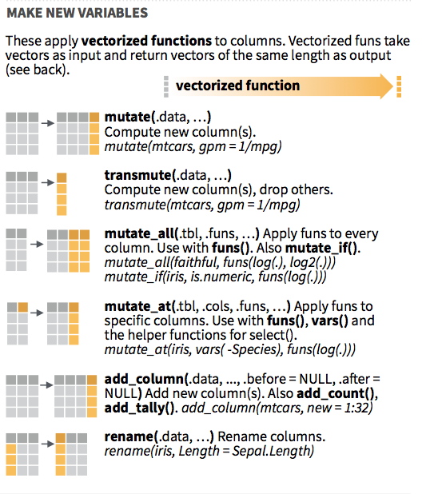

Is it possible that larger families have a lower rate of survival?

To test this hypothesis, create a new variable “FamSize” as the sum of “Parch” and “SibSp” as above, then arrange by decreasing “FamSize”:

```r
# Create new column FamSize (size of family)
# Arrange by decreasing FamSize
passengers %>%
  mutate(FamSize = Parch + SibSp) %>%
  arrange(desc(FamSize))
```

```
## # A tibble: 891 × 13
##    PassengerId Survived Pclass Name   Sex     Age SibSp Parch Ticket  Fare Cabin
##          <dbl>    <dbl>  <dbl> <chr>  <chr> <dbl> <dbl> <dbl> <chr>  <dbl> <chr>
##  1         160        0      3 "Sage… male     NA     8     2 CA. 2…  69.6 <NA>
##  2         181        0      3 "Sage… fema…    NA     8     2 CA. 2…  69.6 <NA>
##  3         202        0      3 "Sage… male     NA     8     2 CA. 2…  69.6 <NA>
##  4         325        0      3 "Sage… male     NA     8     2 CA. 2…  69.6 <NA>
##  5         793        0      3 "Sage… fema…    NA     8     2 CA. 2…  69.6 <NA>
##  6         847        0      3 "Sage… male     NA     8     2 CA. 2…  69.6 <NA>
##  7         864        0      3 "Sage… fema…    NA     8     2 CA. 2…  69.6 <NA>
##  8          60        0      3 "Good… male     11     5     2 CA 21…  46.9 <NA>
##  9          72        0      3 "Good… fema…    16     5     2 CA 21…  46.9 <NA>
## 10         387        0      3 "Good… male      1     5     2 CA 21…  46.9 <NA>
## # … with 881 more rows, and 2 more variables: Embarked <chr>, FamSize <dbl>
```

**Try on your own**

We are interested in how different passenger characteristics relates to survival. As we move on to the next steps, we might want a more informative survival data than the current `Survived` data which is represented as zeros and ones. We can mutate the values of the “Survived” variable to strings “No” and “Yes” using the `ifelse()` function. Use the `?function()` syntax to look up the manual page for the `ifelse()` function. What do you think the code should be?

*hint: if you’re stuck review the anatomy of a manual page*

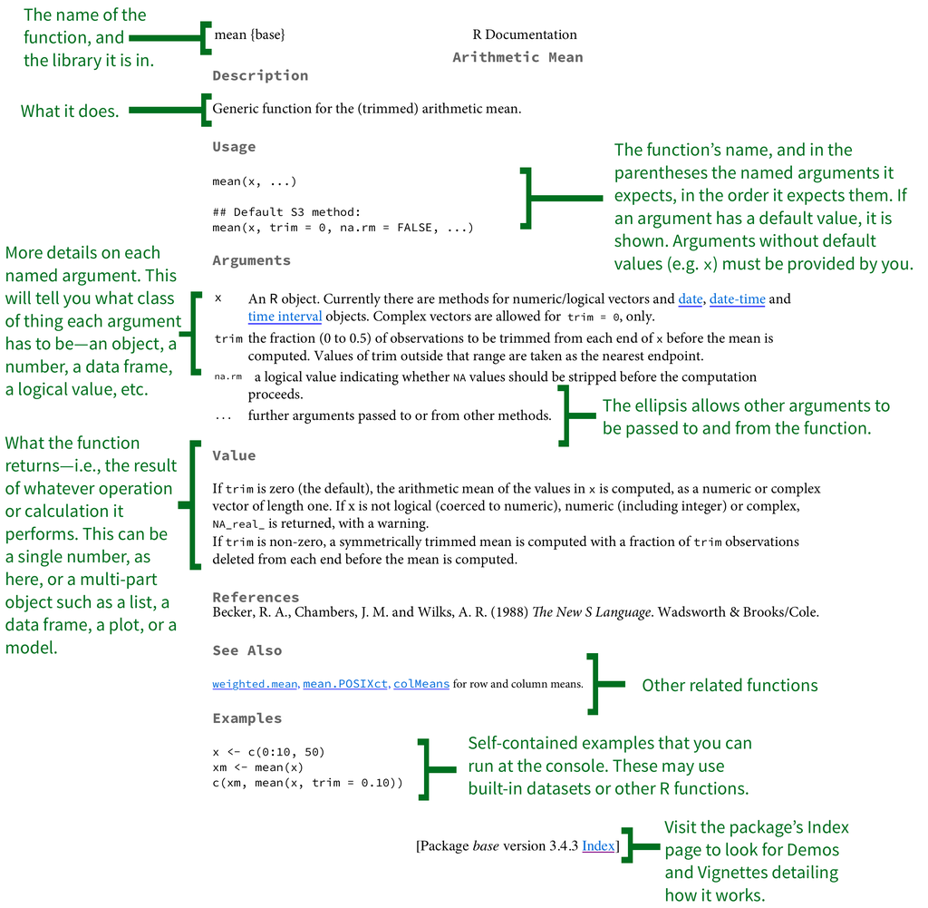

```r
# Turn numerical values of Survived column to "No" & "Yes"
passengers %>%
  mutate(Survived = ifelse(Survived == 0, "No", "Yes"))
```

```
## # A tibble: 891 × 12
##    PassengerId Survived Pclass Name   Sex     Age SibSp Parch Ticket  Fare Cabin
##          <dbl> <chr>     <dbl> <chr>  <chr> <dbl> <dbl> <dbl> <chr>  <dbl> <chr>
##  1           1 No            3 Braun… male     22     1     0 A/5 2…  7.25 <NA>
##  2           2 Yes           1 Cumin… fema…    38     1     0 PC 17… 71.3  C85
##  3           3 Yes           3 Heikk… fema…    26     0     0 STON/…  7.92 <NA>
##  4           4 Yes           1 Futre… fema…    35     1     0 113803 53.1  C123
##  5           5 No            3 Allen… male     35     0     0 373450  8.05 <NA>
##  6           6 No            3 Moran… male     NA     0     0 330877  8.46 <NA>
##  7           7 No            1 McCar… male     54     0     0 17463  51.9  E46
##  8           8 No            3 Palss… male      2     3     1 349909 21.1  <NA>
##  9           9 Yes           3 Johns… fema…    27     0     2 347742 11.1  <NA>
## 10          10 Yes           2 Nasse… fema…    14     1     0 237736 30.1  <NA>
## # … with 881 more rows, and 1 more variable: Embarked <chr>
```

So far, our new variables have just been printed to the console, but not saved. If we want to explore our new variable further we will save it as a new dataframe called `passengers1`. The way we create and save this new object is similar to how the data was loaded using assingment arrow `<-`. The shortcut for the assignment arrow is *option+dash*.

```r
# Turn numerical values of Survived column to "No" & "Yes" (new dataframe)
passengers1 <- passengers %>%
  mutate(Survived = ifelse(Survived == 0, "No", "Yes"))
passengers1
```

```
## # A tibble: 891 × 12
##    PassengerId Survived Pclass Name   Sex     Age SibSp Parch Ticket  Fare Cabin
##          <dbl> <chr>     <dbl> <chr>  <chr> <dbl> <dbl> <dbl> <chr>  <dbl> <chr>
##  1           1 No            3 Braun… male     22     1     0 A/5 2…  7.25 <NA>
##  2           2 Yes           1 Cumin… fema…    38     1     0 PC 17… 71.3  C85
##  3           3 Yes           3 Heikk… fema…    26     0     0 STON/…  7.92 <NA>
##  4           4 Yes           1 Futre… fema…    35     1     0 113803 53.1  C123
##  5           5 No            3 Allen… male     35     0     0 373450  8.05 <NA>
##  6           6 No            3 Moran… male     NA     0     0 330877  8.46 <NA>
##  7           7 No            1 McCar… male     54     0     0 17463  51.9  E46
##  8           8 No            3 Palss… male      2     3     1 349909 21.1  <NA>
##  9           9 Yes           3 Johns… fema…    27     0     2 347742 11.1  <NA>
## 10          10 Yes           2 Nasse… fema…    14     1     0 237736 30.1  <NA>
## # … with 881 more rows, and 1 more variable: Embarked <chr>
```

Commonly used verbs (`dplyr` package):

- select() select columns
- filter() filter rows
- arrange() re-order or arrange rows
- mutate() create new columns
- summarise() summarise values
- group_by() allows for group operations in the “split-apply-combine” concept

Reference the `dplyr` [cheatsheet](https://www.rstudio.com/resources/cheatsheets/), or [package vignette](https://cran.r-project.org/web/packages/dplyr/vignettes/dplyr.html) for more details.

**Recap:**

- You’ve imported your data & checked it out
- You’ve learnt about the pipe operator `%>%`
- You can now use `dplyr` to wrangle your data: `filter` it, `arrange` it and create new features by `mutating` old ones.

**Up next:**

- You’ll learn how to easily and intuitively plot your data using `ggplot2`.